# Basic R workshop - README

Welcome! Here are some instructions to get ready for the basic R workshop at the Max Planck Institute for Marine Microbiology.

## Downloading R and RStudio

Different R versions can be downloaded from the [Comprehensive R Archive Network website](https://cran.r-project.org/). RStudio can be downloaded from its [website](https://www.rstudio.com/products/rstudio/download/). In both cases, choose the latest version available for your operating system.

The download and installation should be pretty straight-forward, if you have trouble check this [link](https://courses.edx.org/courses/UTAustinX/UT.7.01x/3T2014/56c5437b88fa43cf828bff5371c6a924/). If you still have troubles, don’t worry, we’ll help you before the workshop.

## Getting the workshop “syllabus”

1. Go to the [workshop GitHub repository](https://github.com/mschecht/basic_R) (you should already be there if you are reading this ;))
2. Click on `Clone or download`, then click `Download ZIP`. Save this file somewhere useful on your local computer.

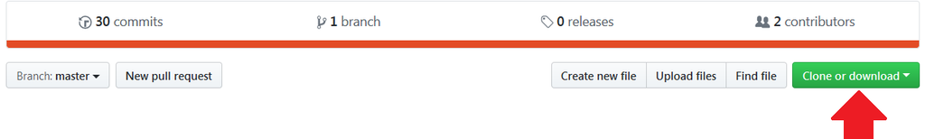

3. Unzip file `basic_R-master`
4. Open the file `workshop_notebook.html` in your browser. This file contains the guide to the workshop.

## Credits

The contents of this workshop were adapted from [“Curso básico de R”](http://www.ub.edu/stat/docencia/EADB/Curso%20basico%20de%20R.pdf) by Francesc Carmona, the [P2P course](https://rawgit.com/genomewalker/p2p/master/friday/P2P_r_crash_course.html#32_ggplot2) by Antonio Fernàndez-Guerra and Pelin Yilmaz and [Happy Belly Bioinformatics’ R basics](https://astrobiomike.github.io/R/basics) by Michael D. Lee.

## Contacts

| Name | GitHub handle | email |
| --- | --- | --- |
| David Benito | @dbenitom | dbenito@mpi-bremen.de |
| [Matthew Schechter](https://orcid.org/0000-0002-8435-3203) | @mschecht | mschecht@mpi-bremen.de |